# MATH425_HouseSellingPrices

Annaka McClelland

## Overview of this Assignment

```r
library(tidyverse)
library(mosaic)
library(pander)

train_df <- read.csv("C:/Users/.../OneDrive/College/MATH425/MATH325/Statistics-Notebook-master/Analyses/Linear Regression/MATH425/MATH425_W10/train.csv", stringsAsFactors = TRUE)
test_df <- read.csv("C:/Users/.../OneDrive/College/MATH425/MATH325/Statistics-Notebook-master/Analyses/Linear Regression/MATH425/MATH425_W10/test.csv", stringsAsFactors = TRUE)
```

```r
# clean up

train_df <- train_df |>
  # rename(threessnPorch = `3SsnPorch`) |>
  mutate(Alley = as.character(Alley),
         Alley = replace_na(Alley, "No ally access"),
         Alley = as.factor(Alley)) |>
  mutate(GarageQual = as.character(GarageQual),
         GarageQual = replace_na(GarageQual, "No Garage"),
         GarageQual = as.factor(GarageQual)) |>
  mutate(GarageType = as.character(GarageType),
         GarageType = replace_na(GarageType, "No Garage"),
         GarageType = as.factor(GarageType)) |>
  mutate(FireplaceQu = as.character(FireplaceQu),
         FireplaceQu = replace_na(FireplaceQu, "No fireplace"),
         FireplaceQu = as.factor(FireplaceQu)) |>
  mutate(BsmtCond = as.character(BsmtCond),
         BsmtCond = replace_na(BsmtCond, "No basement"),
         BsmtCond = as.factor(BsmtCond)) |>
  mutate(BsmtQual = as.character(BsmtQual),
         BsmtQual = replace_na(BsmtQual, "No basement"),
         BsmtQual = as.factor(BsmtQual)) |>
  mutate(BsmtExposure = as.character(BsmtExposure),
         BsmtExposure = replace_na(BsmtExposure, "No fireplace"),
         BsmtExposure = as.factor(BsmtExposure)) |>
  mutate(TotalSF = X1stFlrSF + X2ndFlrSF + BsmtUnfSF + TotalBsmtSF + WoodDeckSF + OpenPorchSF + EnclosedPorch + ScreenPorch + PoolArea + GarageArea ,
                RichNbrhd = case_when(Neighborhood %in% c("StoneBr", "NridgHt", "NoRidge") ~ 1,
                                                          TRUE ~ 0)) |>
  mutate(PoolQC = as.character(PoolQC),
         PoolQC = replace_na(PoolQC, "No Pool"),
         PoolQC = as.factor(PoolQC)) |>
  mutate( # "housing_crisis" for outliers (Dec 2007 - Jun 2009)

    Housing_Crisis = case_when(
      (YrSold == 2007 & MoSold == 12) |
      (YrSold == 2008) |
      (YrSold == 2009 & MoSold <= 6) ~ 1,
      TRUE ~ 2
    )
  ) |>
  mutate(TotalSF2 = X1stFlrSF + X2ndFlrSF + TotalBsmtSF)
```

## Data Table

```r
library(DT)
# data table here first 5 rows
datatable(train_df, options = list(pageLength = 5, autoWidth = TRUE))
```

|  | Id | MSSubClass | MSZoning | LotFrontage | LotArea | Street | Alley | LotShape | LandContour | Utilities | LotConfig | LandSlope | Neighborhood | Condition1 | Condition2 | BldgType | HouseStyle | OverallQual | OverallCond | YearBuilt | YearRemodAdd | RoofStyle | RoofMatl | Exterior1st | Exterior2nd | MasVnrType | MasVnrArea | ExterQual | ExterCond | … |
| --- | --- | --- | --- | --- | --- | --- | --- | --- | --- | --- | --- | --- | --- | --- | --- | --- | --- | --- | --- | --- | --- | --- | --- | --- | --- | --- | --- | --- | --- | --- |
| 1 | 1 | 60 | RL | 65 | 8450 | Pave | No ally access | Reg | Lvl | AllPub | Inside | Gtl | CollgCr | Norm | Norm | 1Fam | 2Story | 7 | 5 | 2003 | 2003 | Gable | CompShg | VinylSd | VinylSd | BrkFace | 196 | Gd | TA | … |
| 2 | 2 | 20 | RL | 80 | 9600 | Pave | No ally access | Reg | Lvl | AllPub | FR2 | Gtl | Veenker | Feedr | Norm | 1Fam | 1Story | 6 | 8 | 1976 | 1976 | Gable | CompShg | MetalSd | MetalSd | None | 0 | TA | TA | … |
| 3 | 3 | 60 | RL | 68 | 11250 | Pave | No ally access | IR1 | Lvl | AllPub | Inside | Gtl | CollgCr | Norm | Norm | 1Fam | 2Story | 7 | 5 | 2001 | 2002 | Gable | CompShg | VinylSd | VinylSd | BrkFace | 162 | Gd | TA | … |
| 4 | 4 | 70 | RL | 60 | 9550 | Pave | No ally access | IR1 | Lvl | AllPub | Corner | Gtl | Crawfor | Norm | Norm | 1Fam | 2Story | 7 | 5 | 1915 | 1970 | Gable | CompShg | Wd Sdng | Wd Shng | None | 0 | TA | TA | … |
| 5 | 5 | 60 | RL | 84 | 14260 | Pave | No ally access | IR1 | Lvl | AllPub | FR2 | Gtl | NoRidge | Norm | Norm | 1Fam | 2Story | 8 | 5 | 2000 | 2000 | Gable | CompShg | VinylSd | VinylSd | BrkFace | 350 | Gd | TA | … |
| 6 | 6 | 50 | RL | 85 | 14115 | Pave | No ally access | IR1 | Lvl | AllPub | Inside | Gtl | Mitchel | Norm | Norm | 1Fam | 1.5Fin | 5 | 5 | 1993 | 1995 | Gable | CompShg | VinylSd | VinylSd | None | 0 | TA | TA | … |
| 7 | 7 | 20 | RL | 75 | 10084 | Pave | No ally access | Reg | Lvl | AllPub | Inside | Gtl | Somerst | Norm | Norm | 1Fam | 1Story | 8 | 5 | 2004 | 2005 | Gable | CompShg | VinylSd | VinylSd | Stone | 186 | Gd | TA | … |
| 8 | 8 | 60 | RL |  | 10382 | Pave | No ally access | IR1 | Lvl | AllPub | Corner | Gtl | NWAmes | PosN | Norm | 1Fam | 2Story | 7 | 6 | 1973 | 1973 | Gable | CompShg | HdBoard | HdBoard | Stone | 240 | TA | TA | … |
| 9 | 9 | 50 | RM | 51 | 6120 | Pave | No ally access | Reg | Lvl | AllPub | Inside | Gtl | OldTown | Artery | Norm | 1Fam | 1.5Fin | 7 | 5 | 1931 | 1950 | Gable | CompShg | BrkFace | Wd Shng | None | 0 | TA | TA | … |
| 10 | 10 | 190 | RL | 50 | 7420 | Pave | No ally access | Reg | Lvl | AllPub | Corner | Gtl | BrkSide | Artery | Artery | 2fmCon | 1.5Unf | 5 | 6 | 1939 | 1950 | Gable | CompShg | MetalSd | MetalSd | None | 0 | TA | TA | … |

[output cut: 1450 more lines]

## Results

```r
# final lm here
final.lm <- lm(formula = log(SalePrice) ~ TotalSF + GrLivArea +
    YearRemodAdd + GarageCars + Fireplaces + KitchenQual + BsmtQual +
    PoolQC + Neighborhood + TotalSF:KitchenQual + TotalSF:OverallQual,
    data = train_df)

# pander(summary(final.lm))
summary(final.lm)
```

```
##
## Call:
## lm(formula = log(SalePrice) ~ TotalSF + GrLivArea + YearRemodAdd +
##     GarageCars + Fireplaces + KitchenQual + BsmtQual + PoolQC +
##     Neighborhood + TotalSF:KitchenQual + TotalSF:OverallQual,
##     data = train_df)
##
## Residuals:
##      Min       1Q   Median       3Q      Max
## -0.97745 -0.07100  0.00588  0.08724  0.58185
##
## Coefficients:
##                         Estimate Std. Error t value Pr(>|t|)
## (Intercept)            7.696e+00  5.855e-01  13.145  < 2e-16 ***
## TotalSF               -1.625e-04  1.748e-05  -9.297  < 2e-16 ***
## GrLivArea              2.142e-04  1.436e-05  14.919  < 2e-16 ***
## YearRemodAdd           2.200e-03  2.837e-04   7.755 1.68e-14 ***
## GarageCars             7.513e-02  7.777e-03   9.662  < 2e-16 ***
## Fireplaces             6.473e-02  7.557e-03   8.566  < 2e-16 ***
## KitchenQualFa         -9.488e-01  8.825e-02 -10.751  < 2e-16 ***
## KitchenQualGd         -6.063e-01  6.002e-02 -10.102  < 2e-16 ***
## KitchenQualTA         -6.012e-01  6.194e-02  -9.707  < 2e-16 ***
## BsmtQualFa            -1.901e-01  3.523e-02  -5.397 7.92e-08 ***
## BsmtQualGd            -8.762e-02  1.946e-02  -4.502 7.29e-06 ***
## BsmtQualNo basement   -3.038e-01  3.568e-02  -8.513  < 2e-16 ***
## BsmtQualTA            -1.196e-01  2.300e-02  -5.198 2.31e-07 ***
## PoolQCFa              -9.475e-03  1.538e-01  -0.062 0.950897
## PoolQCGd              -1.749e-01  1.402e-01  -1.247 0.212625
## PoolQCNo Pool          2.098e-02  1.097e-01   0.191 0.848351
## NeighborhoodBlueste   -1.084e-01  1.135e-01  -0.955 0.339805
## NeighborhoodBrDale    -1.460e-01  5.563e-02  -2.624 0.008786 **
## NeighborhoodBrkSide   -4.814e-03  4.468e-02  -0.108 0.914217
## NeighborhoodClearCr    1.965e-01  4.786e-02   4.105 4.27e-05 ***
## NeighborhoodCollgCr    1.153e-01  3.902e-02   2.955 0.003175 **
## NeighborhoodCrawfor    1.698e-01  4.426e-02   3.836 0.000130 ***
## NeighborhoodEdwards   -2.369e-02  4.229e-02  -0.560 0.575443
## NeighborhoodGilbert    6.898e-02  4.121e-02   1.674 0.094367 .
## NeighborhoodIDOTRR    -1.750e-01  4.755e-02  -3.681 0.000241 ***
## NeighborhoodMeadowV   -2.284e-01  5.393e-02  -4.234 2.44e-05 ***
## NeighborhoodMitchel    7.232e-02  4.407e-02   1.641 0.101013
```

[output cut: 8 more lines]

```
## NeighborhoodSomerst    1.242e-01  4.037e-02   3.077 0.002134 **
## NeighborhoodStoneBr    2.412e-01  4.814e-02   5.009 6.15e-07 ***
## NeighborhoodSWISU     -2.107e-02  5.094e-02  -0.414 0.679269
## NeighborhoodTimber     1.390e-01  4.451e-02   3.123 0.001824 **
## NeighborhoodVeenker    2.201e-01  5.877e-02   3.745 0.000188 ***
## TotalSF:KitchenQualFa  1.867e-04  2.420e-05   7.718 2.22e-14 ***
## TotalSF:KitchenQualGd  1.085e-04  1.136e-05   9.547  < 2e-16 ***
## TotalSF:KitchenQualTA  9.899e-05  1.323e-05   7.482 1.28e-13 ***
## TotalSF:OverallQual    1.277e-05  1.378e-06   9.265  < 2e-16 ***
## ---
## Signif. codes:  0 '***' 0.001 '**' 0.01 '*' 0.05 '.' 0.1 ' ' 1
##
## Residual standard error: 0.1505 on 1416 degrees of freedom
## Multiple R-squared:  0.8622, Adjusted R-squared:  0.858
## F-statistic: 206.1 on 43 and 1416 DF,  p-value: < 2.2e-16
```

### Graphing of Model

```r
# Find some way to visually present your final model, even if it is just one dimension at a time.
# library(plotly)
# library(broom)
# library(ggplot2)
#
# # Tidy up the model output to extract estimates and standard errors
# tidy_model <- broom::tidy(final.lm)
#
# ggplot(tidy_model, aes(x = reorder(term, estimate), y = estimate)) +
#   geom_point() +
#   geom_errorbar(aes(ymin = estimate - 1.96 * std.error,
#                     ymax = estimate + 1.96 * std.error),
#                 width = 0.2) +
#   coord_flip() +
#   labs(title = "Coefficient Plot for Final Model",
#        x = "Predictor",
#        y = "Coefficient Estimate")
```

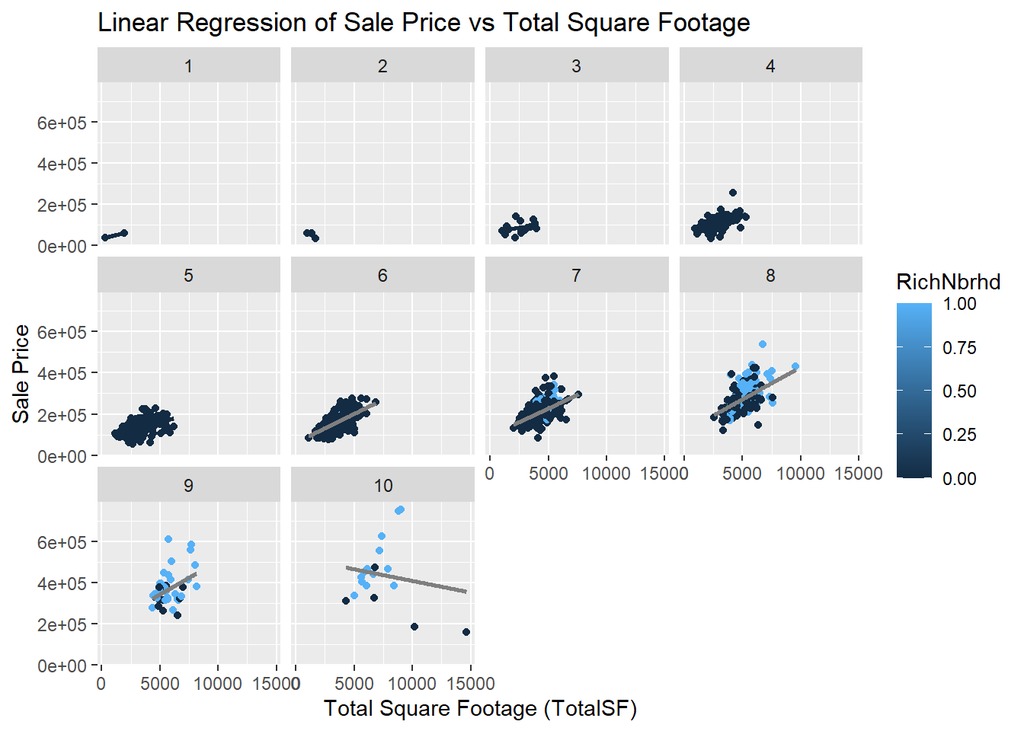

```r
# create graph of lm to data
ggplot(train_df, aes(x = TotalSF, y = SalePrice, color = RichNbrhd)) +
  geom_point() +
  facet_wrap(~ OverallQual) +
  geom_smooth(method = "lm", se = FALSE) +
  labs(title = "Linear Regression of Sale Price vs Total Square Footage",
       x = "Total Square Footage (TotalSF)",
       y = "Sale Price")
```

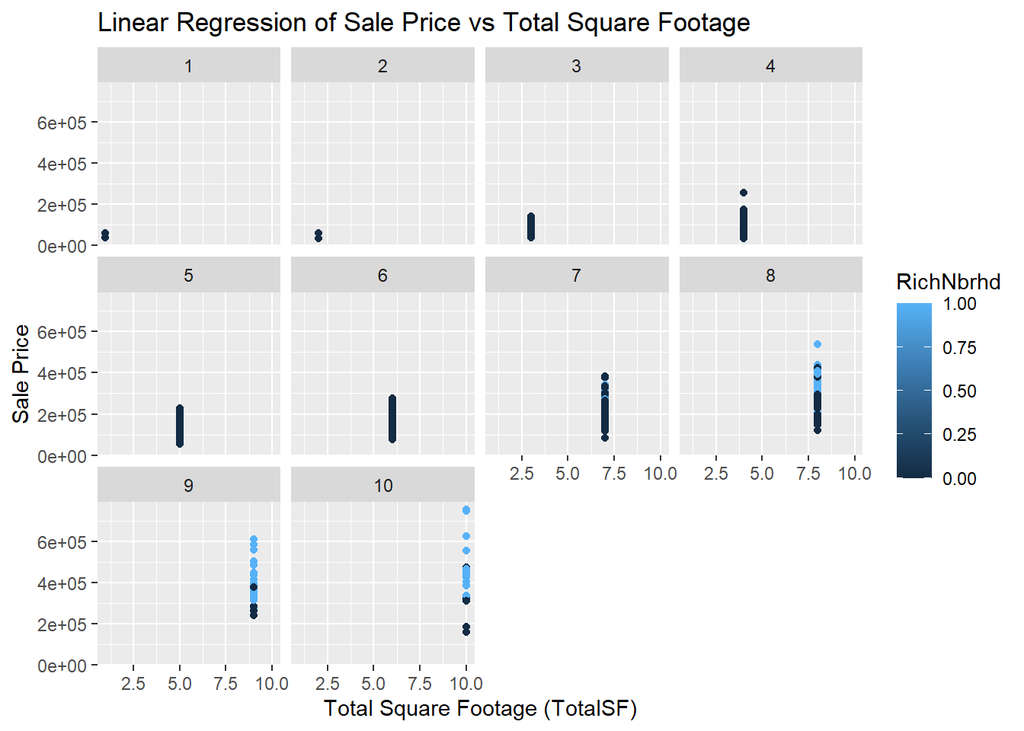

```r
ggplot(train_df, aes(x = OverallQual, y = SalePrice, color = RichNbrhd)) +
  geom_point() +
  facet_wrap(~ OverallQual) +
  geom_smooth(method = "lm", se = FALSE) +
  labs(title = "Linear Regression of Sale Price vs Total Square Footage",
       x = "Total Square Footage (TotalSF)",
       y = "Sale Price")
```

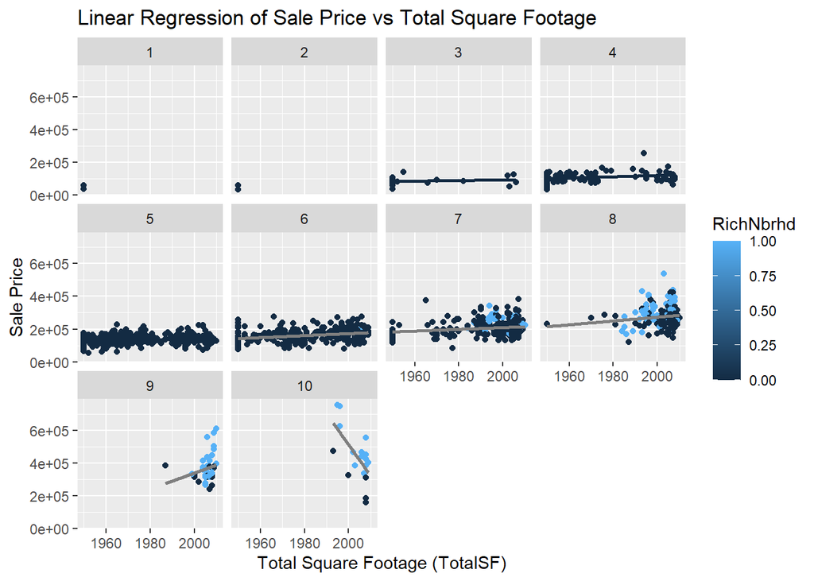

```r
ggplot(train_df, aes(x = YearRemodAdd, y = SalePrice, color = RichNbrhd)) +
  geom_point() +
  facet_wrap(~ OverallQual) +
  geom_smooth(method = "lm", se = FALSE) +
  labs(title = "Linear Regression of Sale Price vs Total Square Footage",
       x = "Total Square Footage (TotalSF)",
       y = "Sale Price")
```

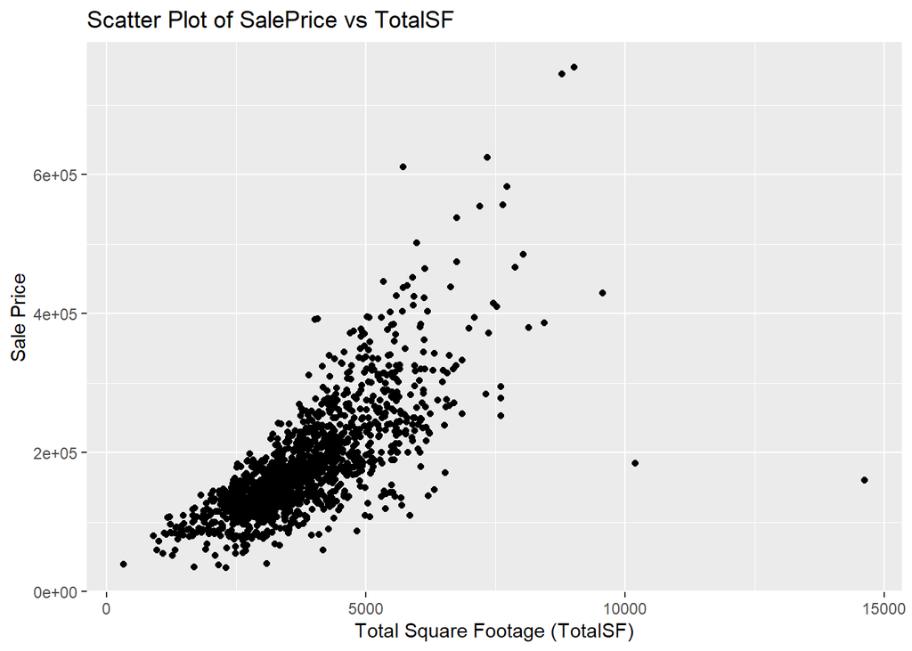

```r
# graph of x-values and their correlation to the y-value (salesprice)

# Create a scatter plot of SalePrice vs TotalSF
ggplot(train_df, aes(x = TotalSF, y = SalePrice)) +
  geom_point() +
  labs(title = "Scatter Plot of SalePrice vs TotalSF",
       x = "Total Square Footage (TotalSF)",
       y = "Sale Price")
```

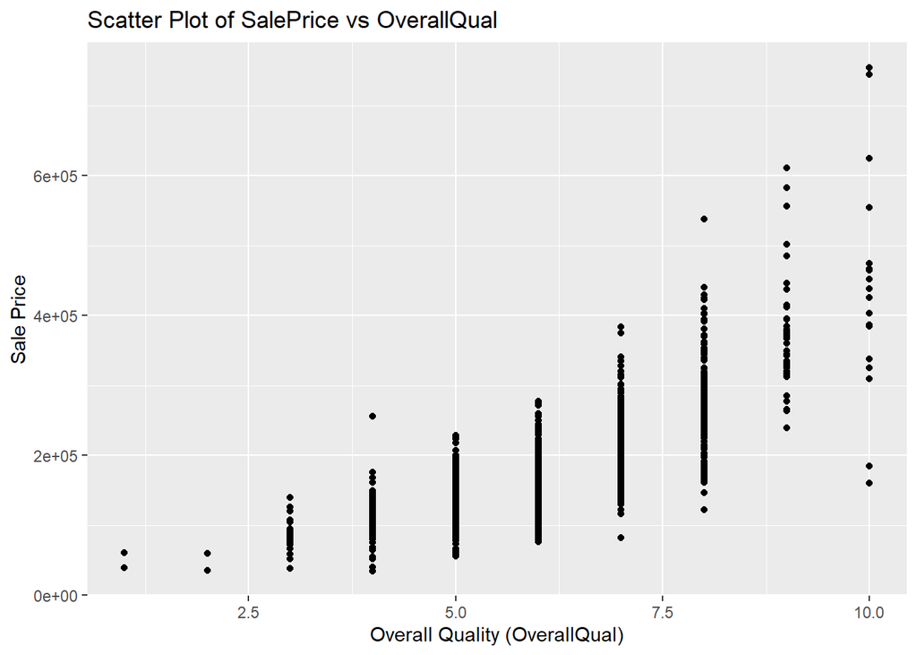

```r
# Create a scatter plot of SalePrice vs OverallQual
ggplot(train_df, aes(x = OverallQual, y = SalePrice)) +
  geom_point() +
  labs(title = "Scatter Plot of SalePrice vs OverallQual",
       x = "Overall Quality (OverallQual)",
       y = "Sale Price")
```

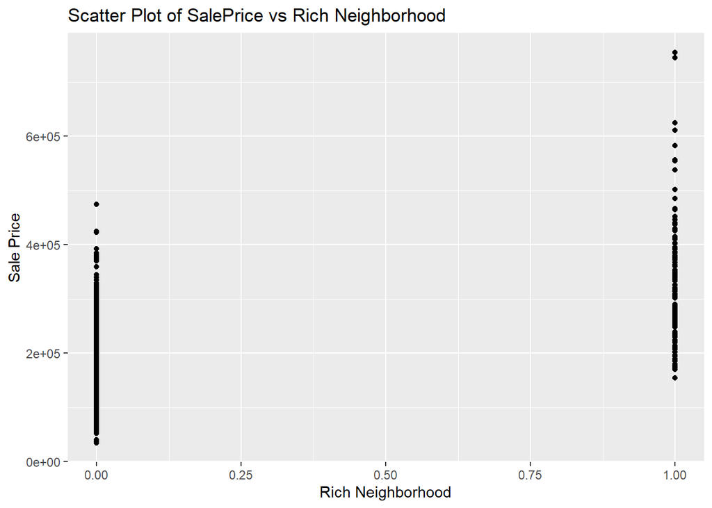

```r
# Create a scatter plot of SalePrice vs RichNbrhd
ggplot(train_df, aes(x = RichNbrhd, y = SalePrice)) +
  geom_point() +
  labs(title = "Scatter Plot of SalePrice vs Rich Neighborhood",
       x = "Rich Neighborhood",
       y = "Sale Price")
```

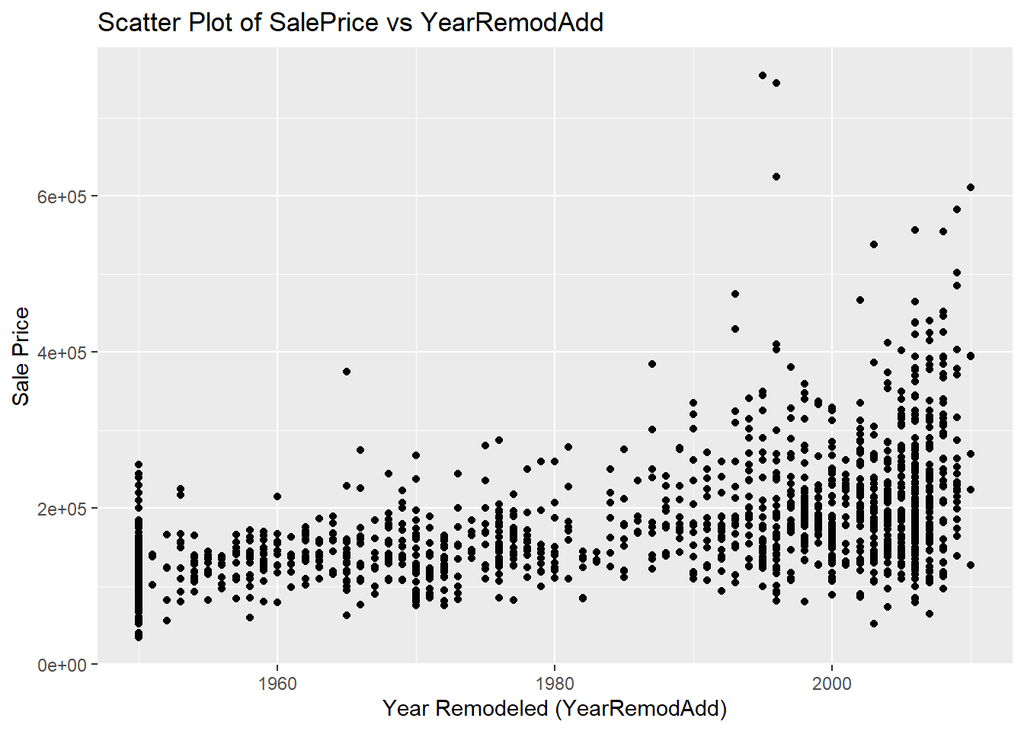

```r
# Create a scatter plot of SalePrice vs YearRemodAdd
ggplot(train_df, aes(x = YearRemodAdd, y = SalePrice)) +
  geom_point() +
  labs(title = "Scatter Plot of SalePrice vs YearRemodAdd",
       x = "Year Remodeled (YearRemodAdd)",
       y = "Sale Price")
```

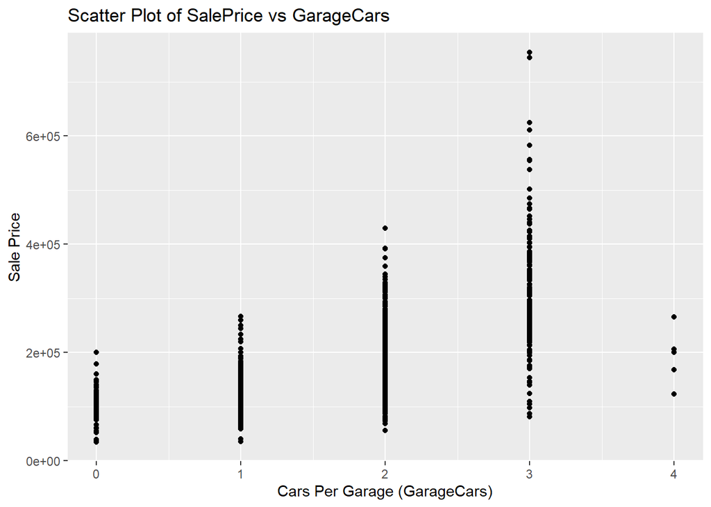

```r
# Create a scatter plot of SalePrice vs GarageCars
ggplot(train_df, aes(x = GarageCars, y = SalePrice)) +
  geom_point() +
  labs(title = "Scatter Plot of SalePrice vs GarageCars",
       x = "Cars Per Garage (GarageCars)",
       y = "Sale Price")
```

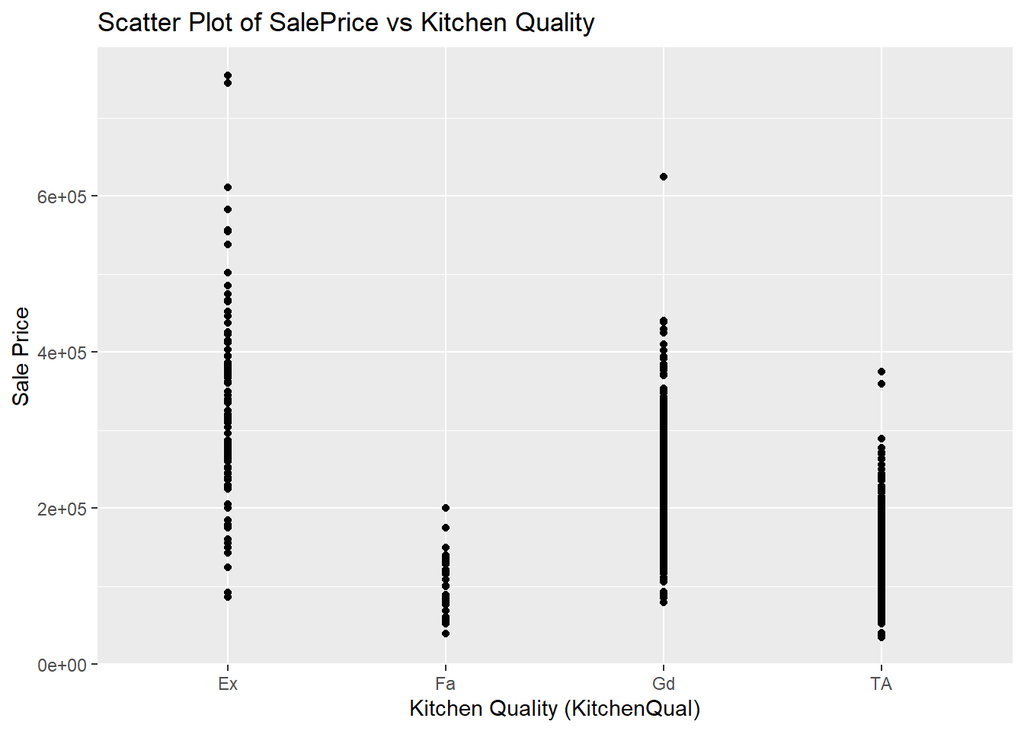

```r
# Create a scatter plot of SalePrice vs KitchenQual
ggplot(train_df, aes(x = KitchenQual, y = SalePrice)) +
  geom_point() +
  labs(title = "Scatter Plot of SalePrice vs Kitchen Quality",
       x = "Kitchen Quality (KitchenQual)",
       y = "Sale Price")
```

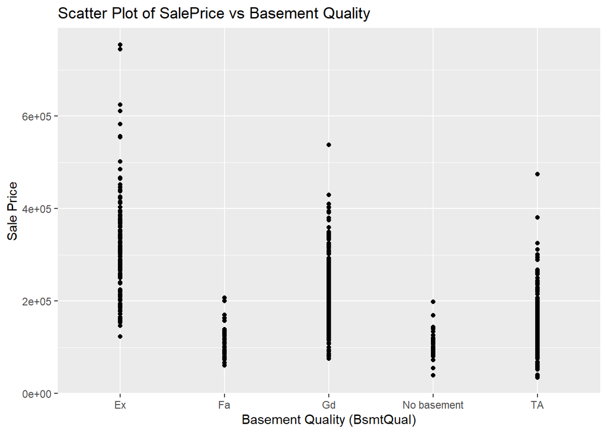

```r
# Create a scatter plot of SalePrice vs BsmtQual
ggplot(train_df, aes(x = BsmtQual, y = SalePrice)) +
  geom_point() +
  labs(title = "Scatter Plot of SalePrice vs Basement Quality",
       x = "Basement Quality (BsmtQual)",
       y = "Sale Price")
```

```r
# Create a scatter plot of SalePrice vs PoolQC
# ggplot(train_df, aes(x = PoolQC, y = SalePrice)) +
#   geom_point() +
#   labs(title = "Scatter Plot of SalePrice vs Pool Quality",
#        x = "Pool Quality (PoolQC)",
#        y = "Sale Price") +
#   stat_function(fun=function(PoolQC), place your estimates here)
```

```r
# # Create a scatter plot of SalePrice vs Housing_Crisis
# ggplot(train_df, aes(x = Housing_Crisis, y = SalePrice)) +
#   geom_point() +
#   labs(title = "Scatter Plot of SalePrice vs Housing_Crisis",
#        x = "Housing Crisis",
#        y = "Sale Price")
```

### Interpretation of Model

This log-linear model for SalePrice incorporates both continuous variables (like TotalSF, GrLivArea, YearRemodAdd, GarageCars, and Fireplaces) and categorical variables (such as KitchenQual, BsmtQual, PoolQC, and Neighborhood), with interactions between TotalSF and quality measures. Because the response is log(SalePrice), each coefficient approximates the percentage change in sale price for a one-unit change in the predictor—for instance, each additional square foot of GrLivArea is associated with about a 0.02% increase in price, while the negative TotalSF coefficient suggests that, when controlling for GrLivArea, extra non-living area slightly detracts from value. The categorical variables indicate how different quality levels and neighborhoods deviate from a reference category, with lower quality ratings in kitchens and basements significantly reducing price.

## Validation

```r
set.seed(90)
num_rows <- 1000 #1460 total
keep <- sample(1:nrow(train_df), num_rows)
mytrain <- train_df[keep, ] #Use this in the lm(..., data=mytrain)
mytest <- train_df[-keep, ] #Use this in the predict(..., newdata=mytest)

yh_hd <- predict(final.lm, newdata=mytest)
ybar <- (mean( log(mytest$SalePrice)))
SSTO <- sum( ( log(mytest$SalePrice) - ybar)^2 )
SSE_hd <- sum( ( log(mytest$SalePrice) - yh_hd)^2 )
rs_hd <- 1 - SSE_hd/SSTO
n <- nrow(mytest)
p_hd <- length(final.lm)
rsa_hd <- 1 - (n-1)/(n-p_hd)*SSE_hd/SSTO

# r-squared adjusted
# rsa_hd

adj_r2 <- round(summary(final.lm)$adj.r.squared, 2)
cat("Adjusted R-squared:", adj_r2, "\n")
```

```
## Adjusted R-squared: 0.86
```

```r
rsa_hd_r2 <- round(rsa_hd, 2)
cat("Validation R-squared:", rsa_hd_r2, "\n")
```

```
## Validation R-squared: 0.84
```

```r
# validation current: 0.8515619 GTG
# Adjusted R-squared: 0.8433
```

## Scratch Work

```r
# create new x-axis
```

```r
# three variables rchn totalsf and overallqual
```

```r
# robust regression
library(MASS)
robustlm.OverallQual <- rlm(SalePrice ~ TotalSF + OverallQual + TotalSF:OverallQual + TotalSF:Housing_Crisis + TotalSF:Housing_Crisis:YrSold, data=mytrain)
summary(robustlm.OverallQual)
```

```
##
## Call: rlm(formula = SalePrice ~ TotalSF + OverallQual + TotalSF:OverallQual +
##     TotalSF:Housing_Crisis + TotalSF:Housing_Crisis:YrSold, data = mytrain)
## Residuals:
##       Min        1Q    Median        3Q       Max
## -639506.4  -18984.3     904.1   19158.3  222790.1
##
## Coefficients:
##                               Value      Std. Error t value
## (Intercept)                   70076.2917 11137.7136     6.2918
## TotalSF                         -18.2156     3.2802    -5.5532
## OverallQual                    2784.6951  1786.0832     1.5591
## TotalSF:OverallQual               6.5922     0.4093    16.1046
## TotalSF:Housing_Crisis           18.9393   205.7260     0.0921
## TotalSF:Housing_Crisis:YrSold    -0.0093     0.1025    -0.0907
##
## Residual standard error: 28340 on 994 degrees of freedom
```

```r
# BEST ONE SO FAR
# 0.7534

#### 0.6254 r-squared for OverallQual ######
lm.OverallQual <- lm(SalePrice ~ TotalSF + OverallQual + TotalSF:OverallQual + TotalSF:Housing_Crisis + TotalSF:Housing_Crisis:YrSold, data=mytrain)
summary(lm.OverallQual)
```

```
##
## Call:
## lm(formula = SalePrice ~ TotalSF + OverallQual + TotalSF:OverallQual +
##     TotalSF:Housing_Crisis + TotalSF:Housing_Crisis:YrSold, data = mytrain)
##
## Residuals:
##     Min      1Q  Median      3Q     Max
## -486198  -21845    -644   18213  274786
##
## Coefficients:
##                                 Estimate Std. Error t value Pr(>|t|)
## (Intercept)                   -2.172e+03  1.522e+04  -0.143    0.887
## TotalSF                       -6.481e+00  4.482e+00  -1.446    0.148
## OverallQual                    1.735e+04  2.440e+03   7.111 2.20e-12 ***
## TotalSF:OverallQual            3.711e+00  5.593e-01   6.635 5.32e-11 ***
## TotalSF:Housing_Crisis        -5.227e+01  2.811e+02  -0.186    0.853
## TotalSF:Housing_Crisis:YrSold  2.695e-02  1.401e-01   0.192    0.847
## ---
## Signif. codes:  0 '***' 0.001 '**' 0.01 '*' 0.05 '.' 0.1 ' ' 1
##
## Residual standard error: 43900 on 994 degrees of freedom
## Multiple R-squared:  0.7082, Adjusted R-squared:  0.7068
## F-statistic: 482.6 on 5 and 994 DF,  p-value: < 2.2e-16
```

```r
lm1 <- lm(
  SalePrice ~ TotalSF + OverallQual + Neighborhood + YearBuilt + YearRemodAdd +
    GarageCars + KitchenQual + Fireplaces + FullBath,
  data = train_df
)
summary(lm1)
```

```
##
## Call:
## lm(formula = SalePrice ~ TotalSF + OverallQual + Neighborhood +
##     YearBuilt + YearRemodAdd + GarageCars + KitchenQual + Fireplaces +
##     FullBath, data = train_df)
##
## Residuals:
##     Min      1Q  Median      3Q     Max
## -307064  -17706    -188   14753  272456
##
## Coefficients:
##                       Estimate Std. Error t value Pr(>|t|)
## (Intercept)         -6.543e+05  1.755e+05  -3.729 0.000200 ***
## TotalSF              1.329e+01  1.195e+00  11.121  < 2e-16 ***
## OverallQual          1.440e+04  1.237e+03  11.641  < 2e-16 ***
## NeighborhoodBlueste  5.087e+03  2.645e+04   0.192 0.847480
## NeighborhoodBrDale   9.855e+03  1.272e+04   0.775 0.438673
## NeighborhoodBrkSide  2.997e+04  1.095e+04   2.737 0.006269 **
## NeighborhoodClearCr  5.635e+04  1.118e+04   5.042 5.19e-07 ***
## NeighborhoodCollgCr  3.390e+04  9.061e+03   3.741 0.000190 ***
## NeighborhoodCrawfor  5.922e+04  1.071e+04   5.527 3.87e-08 ***
## NeighborhoodEdwards  2.348e+04  9.958e+03   2.358 0.018516 *
## NeighborhoodGilbert  2.620e+04  9.496e+03   2.759 0.005880 **
## NeighborhoodIDOTRR   1.772e+04  1.163e+04   1.524 0.127752
## NeighborhoodMeadowV  1.859e+04  1.260e+04   1.475 0.140412
## NeighborhoodMitchel  2.933e+04  1.018e+04   2.880 0.004040 **
## NeighborhoodNAmes    3.214e+04  9.497e+03   3.385 0.000732 ***
## NeighborhoodNoRidge  1.077e+05  1.025e+04  10.513  < 2e-16 ***
## NeighborhoodNPkVill  2.872e+03  1.480e+04   0.194 0.846171
## NeighborhoodNridgHt  6.465e+04  9.634e+03   6.711 2.79e-11 ***
## NeighborhoodNWAmes   2.650e+04  9.756e+03   2.716 0.006679 **
## NeighborhoodOldTown  1.414e+04  1.066e+04   1.326 0.184960
## NeighborhoodSawyer   3.225e+04  1.004e+04   3.213 0.001344 **
## NeighborhoodSawyerW  3.478e+04  9.784e+03   3.555 0.000391 ***
## NeighborhoodSomerst  3.438e+04  9.384e+03   3.664 0.000258 ***
## NeighborhoodStoneBr  8.335e+04  1.119e+04   7.448 1.64e-13 ***
## NeighborhoodSWISU    2.635e+04  1.231e+04   2.140 0.032524 *
## NeighborhoodTimber   4.757e+04  1.032e+04   4.609 4.41e-06 ***
## NeighborhoodVeenker  6.425e+04  1.375e+04   4.673 3.25e-06 ***
## YearBuilt            4.815e+01  7.010e+01   0.687 0.492284
## YearRemodAdd         2.869e+02  6.646e+01   4.317 1.69e-05 ***
## GarageCars           1.153e+04  1.796e+03   6.421 1.84e-10 ***
## KitchenQualFa       -5.281e+04  8.024e+03  -6.581 6.55e-11 ***
## KitchenQualGd       -5.187e+04  4.376e+03 -11.855  < 2e-16 ***
## KitchenQualTA       -5.446e+04  5.083e+03 -10.714  < 2e-16 ***
## Fireplaces           1.326e+04  1.743e+03   7.608 5.03e-14 ***
## FullBath             1.191e+04  2.356e+03   5.055 4.85e-07 ***
## ---
## Signif. codes:  0 '***' 0.001 '**' 0.01 '*' 0.05 '.' 0.1 ' ' 1
##
## Residual standard error: 35150 on 1425 degrees of freedom
## Multiple R-squared:  0.8088, Adjusted R-squared:  0.8042
## F-statistic: 177.3 on 34 and 1425 DF,  p-value: < 2.2e-16
```

```r
lm.full <- lm(
  SalePrice ~ TotalSF + OverallQual + Neighborhood + YearBuilt + YearRemodAdd +
    GarageCars + Fireplaces + FullBath + KitchenQual +
    BsmtQual + PoolQC,
  data = train_df
)

# 2. Use stepwise to prune
lm.step <- step(lm.full, direction = "both", trace = FALSE)
summary(lm.step)
```

```
##
## Call:
## lm(formula = SalePrice ~ TotalSF + OverallQual + Neighborhood +
##     YearRemodAdd + GarageCars + Fireplaces + FullBath + KitchenQual +
##     BsmtQual + PoolQC, data = train_df)
##
## Residuals:
##     Min      1Q  Median      3Q     Max
## -245667  -16666    -510   14392  257591
##
## Coefficients:
##                       Estimate Std. Error t value Pr(>|t|)
## (Intercept)         -3.484e+05  1.298e+05  -2.683 0.007377 **
## TotalSF              1.290e+01  1.236e+00  10.433  < 2e-16 ***
## OverallQual          1.253e+04  1.210e+03  10.354  < 2e-16 ***
## NeighborhoodBlueste  5.655e+03  2.531e+04   0.223 0.823201
## NeighborhoodBrDale   8.244e+03  1.231e+04   0.670 0.503122
## NeighborhoodBrkSide  2.601e+04  9.921e+03   2.621 0.008852 **
## NeighborhoodClearCr  5.481e+04  1.057e+04   5.188 2.44e-07 ***
## NeighborhoodCollgCr  3.485e+04  8.669e+03   4.020 6.13e-05 ***
## NeighborhoodCrawfor  5.598e+04  9.706e+03   5.767 9.90e-09 ***
## NeighborhoodEdwards  2.074e+04  9.366e+03   2.214 0.026959 *
## NeighborhoodGilbert  2.728e+04  9.094e+03   3.000 0.002745 **
## NeighborhoodIDOTRR   1.240e+04  1.057e+04   1.173 0.241070
## NeighborhoodMeadowV  1.519e+04  1.204e+04   1.262 0.207165
## NeighborhoodMitchel  2.404e+04  9.795e+03   2.455 0.014220 *
## NeighborhoodNAmes    2.942e+04  9.040e+03   3.255 0.001161 **
## NeighborhoodNoRidge  1.056e+05  9.804e+03  10.775  < 2e-16 ***
## NeighborhoodNPkVill  3.254e+03  1.413e+04   0.230 0.817941
## NeighborhoodNridgHt  5.271e+04  9.310e+03   5.661 1.82e-08 ***
## NeighborhoodNWAmes   2.709e+04  9.319e+03   2.907 0.003706 **
## NeighborhoodOldTown  1.197e+04  9.343e+03   1.281 0.200522
## NeighborhoodSawyer   2.948e+04  9.586e+03   3.075 0.002142 **
## NeighborhoodSawyerW  3.529e+04  9.340e+03   3.778 0.000165 ***
## NeighborhoodSomerst  3.376e+04  8.983e+03   3.759 0.000178 ***
## NeighborhoodStoneBr  7.910e+04  1.071e+04   7.387 2.55e-13 ***
## NeighborhoodSWISU    2.207e+04  1.112e+04   1.985 0.047337 *
## NeighborhoodTimber   4.099e+04  9.883e+03   4.147 3.57e-05 ***
## NeighborhoodVeenker  6.455e+04  1.311e+04   4.923 9.53e-07 ***
## YearRemodAdd         2.636e+02  6.350e+01   4.151 3.50e-05 ***
## GarageCars           1.033e+04  1.732e+03   5.967 3.05e-09 ***
## Fireplaces           1.385e+04  1.671e+03   8.285 2.70e-16 ***
## FullBath             1.185e+04  2.358e+03   5.023 5.74e-07 ***
## KitchenQualFa       -4.312e+04  7.753e+03  -5.562 3.18e-08 ***
## KitchenQualGd       -3.846e+04  4.417e+03  -8.707  < 2e-16 ***
## KitchenQualTA       -4.279e+04  5.018e+03  -8.528  < 2e-16 ***
## BsmtQualFa          -4.843e+04  7.815e+03  -6.198 7.49e-10 ***
## BsmtQualGd          -4.088e+04  4.249e+03  -9.621  < 2e-16 ***
## BsmtQualNo basement -4.016e+04  7.989e+03  -5.026 5.63e-07 ***
## BsmtQualTA          -4.062e+04  5.044e+03  -8.053 1.69e-15 ***
## PoolQCFa            -1.173e+05  3.416e+04  -3.433 0.000614 ***
## PoolQCGd            -1.959e+05  3.119e+04  -6.280 4.50e-10 ***
## PoolQCNo Pool       -1.216e+05  2.419e+04  -5.026 5.65e-07 ***
## ---
## Signif. codes:  0 '***' 0.001 '**' 0.01 '*' 0.05 '.' 0.1 ' ' 1
##
## Residual standard error: 33640 on 1419 degrees of freedom
## Multiple R-squared:  0.8256, Adjusted R-squared:  0.8207
## F-statistic:   168 on 40 and 1419 DF,  p-value: < 2.2e-16
```

```r
lm3 <- lm(
  log(SalePrice) ~ log(TotalSF) + OverallQual + Neighborhood +
    YearBuilt + GarageCars + KitchenQual,
  data = train_df
)
summary(lm3)
```

```
##
## Call:
## lm(formula = log(SalePrice) ~ log(TotalSF) + OverallQual + Neighborhood +
##     YearBuilt + GarageCars + KitchenQual, data = train_df)
##
## Residuals:
##      Min       1Q   Median       3Q      Max
## -1.01316 -0.08116  0.01052  0.09293  0.57821
##
## Coefficients:
##                      Estimate Std. Error t value Pr(>|t|)
## (Intercept)          6.538769   0.672062   9.729  < 2e-16 ***
## log(TotalSF)         0.332977   0.019249  17.299  < 2e-16 ***
## OverallQual          0.094179   0.005680  16.580  < 2e-16 ***
## NeighborhoodBlueste  0.051982   0.124133   0.419 0.675457
## NeighborhoodBrDale  -0.084617   0.059617  -1.419 0.156020
## NeighborhoodBrkSide  0.105283   0.051362   2.050 0.040565 *
## NeighborhoodClearCr  0.331521   0.052348   6.333 3.21e-10 ***
## NeighborhoodCollgCr  0.140860   0.042396   3.322 0.000915 ***
## NeighborhoodCrawfor  0.334262   0.050203   6.658 3.94e-11 ***
## NeighborhoodEdwards  0.071642   0.046671   1.535 0.124998
## NeighborhoodGilbert  0.173098   0.044452   3.894 0.000103 ***
## NeighborhoodIDOTRR  -0.094367   0.054372  -1.736 0.082853 .
## NeighborhoodMeadowV -0.007310   0.059248  -0.123 0.901831
## NeighborhoodMitchel  0.136081   0.047772   2.849 0.004455 **
## NeighborhoodNAmes    0.144671   0.044390   3.259 0.001144 **
## NeighborhoodNoRidge  0.359285   0.047945   7.494 1.17e-13 ***
## NeighborhoodNPkVill  0.045679   0.069191   0.660 0.509237
## NeighborhoodNridgHt  0.220916   0.045192   4.888 1.13e-06 ***
## NeighborhoodNWAmes   0.171297   0.045677   3.750 0.000184 ***
## NeighborhoodOldTown  0.006403   0.049951   0.128 0.898020
## NeighborhoodSawyer   0.144295   0.047053   3.067 0.002205 **
## NeighborhoodSawyerW  0.148958   0.045865   3.248 0.001190 **
## NeighborhoodSomerst  0.139205   0.043865   3.173 0.001538 **
## NeighborhoodStoneBr  0.270281   0.052421   5.156 2.88e-07 ***
## NeighborhoodSWISU    0.153848   0.057694   2.667 0.007748 **
## NeighborhoodTimber   0.225453   0.048416   4.657 3.51e-06 ***
## NeighborhoodVeenker  0.312566   0.064394   4.854 1.34e-06 ***
## YearBuilt            0.001058   0.000324   3.266 0.001118 **
## GarageCars           0.063054   0.008458   7.455 1.55e-13 ***
## KitchenQualFa       -0.245404   0.036836  -6.662 3.84e-11 ***
## KitchenQualGd       -0.126656   0.020348  -6.224 6.34e-10 ***
## KitchenQualTA       -0.192059   0.023110  -8.311  < 2e-16 ***
## ---
## Signif. codes:  0 '***' 0.001 '**' 0.01 '*' 0.05 '.' 0.1 ' ' 1
##
## Residual standard error: 0.165 on 1428 degrees of freedom
## Multiple R-squared:  0.833,  Adjusted R-squared:  0.8293
## F-statistic: 229.7 on 31 and 1428 DF,  p-value: < 2.2e-16
```

```r
# X1stFlrSF * TotalBsmtSF
# TotalSF:PoolQCGd, Housing_Crisis:PoolQCGd

findingsig.lm <- lm(SalePrice ~ TotalSF*Housing_Crisis*YrSold*RichNbrhd*KitchenQual, train_df)
summary(findingsig.lm)
```

```
##
## Call:
## lm(formula = SalePrice ~ TotalSF * Housing_Crisis * YrSold *
##     RichNbrhd * KitchenQual, data = train_df)
##
## Residuals:
##     Min      1Q  Median      3Q     Max
## -226017  -20799    -526   18800  206894
##
## Coefficients: (14 not defined because of singularities)
##                                                         Estimate Std. Error
## (Intercept)                                            8.038e+08  2.783e+08
## TotalSF                                               -1.729e+05  5.404e+04
## Housing_Crisis                                        -4.579e+08  1.448e+08
## YrSold                                                -4.002e+05  1.386e+05
## RichNbrhd                                             -1.632e+08  5.708e+08
## KitchenQualFa                                         -6.428e+08  3.823e+08
## KitchenQualGd                                         -8.487e+08  2.915e+08
## KitchenQualTA                                         -8.448e+08  2.866e+08
## TotalSF:Housing_Crisis                                 9.528e+04  2.813e+04
## TotalSF:YrSold                                         8.609e+01  2.691e+01
## Housing_Crisis:YrSold                                  2.280e+05  7.213e+04
## TotalSF:RichNbrhd                                      4.215e+04  9.684e+04
## Housing_Crisis:RichNbrhd                               2.758e+07  2.920e+08
## YrSold:RichNbrhd                                       8.130e+04  2.842e+05
## TotalSF:KitchenQualFa                                  1.273e+05  1.269e+05
## TotalSF:KitchenQualGd                                  1.935e+05  5.763e+04
## TotalSF:KitchenQualTA                                  1.880e+05  5.787e+04
## Housing_Crisis:KitchenQualFa                           3.783e+08  1.972e+08
## Housing_Crisis:KitchenQualGd                           4.775e+08  1.516e+08
## Housing_Crisis:KitchenQualTA                           4.792e+08  1.490e+08
## YrSold:KitchenQualFa                                   3.200e+05  1.904e+05
## YrSold:KitchenQualGd                                   4.226e+05  1.451e+05
## YrSold:KitchenQualTA                                   4.206e+05  1.427e+05
## RichNbrhd:KitchenQualFa                                       NA         NA
## RichNbrhd:KitchenQualGd                                1.250e+08  6.838e+08
## RichNbrhd:KitchenQualTA                                8.989e+05  4.280e+05
## TotalSF:Housing_Crisis:YrSold                         -4.744e+01  1.401e+01
## TotalSF:Housing_Crisis:RichNbrhd                      -1.238e+04  4.972e+04
## TotalSF:YrSold:RichNbrhd                              -2.098e+01  4.822e+01
```

[output cut: 91 more lines]

```
## TotalSF:YrSold:RichNbrhd:KitchenQualFa                     NA       NA
## TotalSF:YrSold:RichNbrhd:KitchenQualGd                  0.415 0.678559
## TotalSF:YrSold:RichNbrhd:KitchenQualTA                     NA       NA
## Housing_Crisis:YrSold:RichNbrhd:KitchenQualFa              NA       NA
## Housing_Crisis:YrSold:RichNbrhd:KitchenQualGd           0.105 0.916459
## Housing_Crisis:YrSold:RichNbrhd:KitchenQualTA              NA       NA
## TotalSF:Housing_Crisis:YrSold:RichNbrhd:KitchenQualFa      NA       NA
## TotalSF:Housing_Crisis:YrSold:RichNbrhd:KitchenQualGd  -0.365 0.714798
## TotalSF:Housing_Crisis:YrSold:RichNbrhd:KitchenQualTA      NA       NA
## ---
## Signif. codes:  0 '***' 0.001 '**' 0.01 '*' 0.05 '.' 0.1 ' ' 1
##
## Residual standard error: 39940 on 1410 degrees of freedom
## Multiple R-squared:  0.7557, Adjusted R-squared:  0.7472
## F-statistic:    89 on 49 and 1410 DF,  p-value: < 2.2e-16
```

```r
# X1stFlrSF * TotalBsmtSF
# TotalSF:PoolQCGd, Housing_Crisis:PoolQCGd

# TotalSF:OverallQual
finding <- lm(
  SalePrice ~
    # Main effects + 2-way interaction
    X1stFlrSF * TotalBsmtSF +

    # 2-way interaction
    RichNbrhd:KitchenQual +

    # 3-way interactions
    TotalSF:X1stFlrSF:RichNbrhd +
    TotalBsmtSF:X1stFlrSF:RichNbrhd +
    TotalBsmtSF:X1stFlrSF:OverallQual +

    # 4-way interactions
    TotalBsmtSF:X1stFlrSF:RichNbrhd +
    TotalBsmtSF:X1stFlrSF:RichNbrhd:OverallQual +

    # 5-way interactions
    TotalSF:TotalBsmtSF:X1stFlrSF:RichNbrhd +
    TotalBsmtSF:X1stFlrSF:RichNbrhd:OverallQual,

  data = train_df
)
summary(finding)
```

```
##
## Call:
## lm(formula = SalePrice ~ X1stFlrSF * TotalBsmtSF + RichNbrhd:KitchenQual +
##     TotalSF:X1stFlrSF:RichNbrhd + TotalBsmtSF:X1stFlrSF:RichNbrhd +
##     TotalBsmtSF:X1stFlrSF:OverallQual + TotalBsmtSF:X1stFlrSF:RichNbrhd +
##     TotalBsmtSF:X1stFlrSF:RichNbrhd:OverallQual + TotalSF:TotalBsmtSF:X1stFlrSF:RichNbrhd +
##     TotalBsmtSF:X1stFlrSF:RichNbrhd:OverallQual, data = train_df)
##
## Residuals:
##     Min      1Q  Median      3Q     Max
## -278233  -25095   -7009   25324  241303
##
## Coefficients: (1 not defined because of singularities)
##                                               Estimate Std. Error t value
## (Intercept)                                 -4.279e+04  6.367e+03  -6.720
## X1stFlrSF                                    1.440e+02  6.376e+00  22.581
## TotalBsmtSF                                  1.829e+02  7.445e+00  24.566
## X1stFlrSF:TotalBsmtSF                       -2.078e-01  8.180e-03 -25.406
## RichNbrhd:KitchenQualEx                      3.888e+04  2.095e+04   1.855
## RichNbrhd:KitchenQualFa                             NA         NA      NA
## RichNbrhd:KitchenQualGd                      1.508e+04  1.847e+04   0.816
## RichNbrhd:KitchenQualTA                      2.370e+04  3.324e+04   0.713
## X1stFlrSF:RichNbrhd:TotalSF                  1.455e-02  3.654e-03   3.983
## X1stFlrSF:TotalBsmtSF:RichNbrhd             -5.452e-02  1.762e-02  -3.094
## X1stFlrSF:TotalBsmtSF:OverallQual            1.550e-02  6.592e-04  23.515
## X1stFlrSF:TotalBsmtSF:RichNbrhd:OverallQual -9.476e-04  1.779e-03  -0.533
## X1stFlrSF:TotalBsmtSF:RichNbrhd:TotalSF      4.263e-06  1.612e-06   2.645
##                                             Pr(>|t|)
## (Intercept)                                 2.60e-11 ***
## X1stFlrSF                                    < 2e-16 ***
## TotalBsmtSF                                  < 2e-16 ***
## X1stFlrSF:TotalBsmtSF                        < 2e-16 ***
## RichNbrhd:KitchenQualEx                      0.06373 .
## RichNbrhd:KitchenQualFa                           NA
## RichNbrhd:KitchenQualGd                      0.41452
## RichNbrhd:KitchenQualTA                      0.47593
## X1stFlrSF:RichNbrhd:TotalSF                 7.14e-05 ***
## X1stFlrSF:TotalBsmtSF:RichNbrhd              0.00201 **
## X1stFlrSF:TotalBsmtSF:OverallQual            < 2e-16 ***
## X1stFlrSF:TotalBsmtSF:RichNbrhd:OverallQual  0.59427
## X1stFlrSF:TotalBsmtSF:RichNbrhd:TotalSF      0.00825 **
## ---
## Signif. codes:  0 '***' 0.001 '**' 0.01 '*' 0.05 '.' 0.1 ' ' 1
##
## Residual standard error: 41730 on 1448 degrees of freedom
## Multiple R-squared:  0.7262, Adjusted R-squared:  0.7241
## F-statistic: 349.1 on 11 and 1448 DF,  p-value: < 2.2e-16
```

```r
# min and max dates from data test and train
min(train_df$YrSold)
```

```
## [1] 2006
```

```r
max(train_df$YrSold)
```

```
## [1] 2010
```

```r
lm.1stflr <- lm(SalePrice ~ X1stFlrSF, data=train_df)
summary(lm.1stflr)
```

```
##
## Call:
## lm(formula = SalePrice ~ X1stFlrSF, data = train_df)
##
## Residuals:
##     Min      1Q  Median      3Q     Max
## -460330  -36494  -13164   36291  414547
##
## Coefficients:
##              Estimate Std. Error t value Pr(>|t|)
## (Intercept) 36173.447   5245.728   6.896 7.95e-12 ***
## X1stFlrSF     124.501      4.282  29.078  < 2e-16 ***
## ---
## Signif. codes:  0 '***' 0.001 '**' 0.01 '*' 0.05 '.' 0.1 ' ' 1
##
## Residual standard error: 63220 on 1458 degrees of freedom
## Multiple R-squared:  0.3671, Adjusted R-squared:  0.3666
## F-statistic: 845.5 on 1 and 1458 DF,  p-value: < 2.2e-16
```

```r
lm.alley <- lm(SalePrice ~ Alley, data=train_df)
summary(lm.alley)
```

```
##
## Call:
## lm(formula = SalePrice ~ Alley, data = train_df)
##
## Residuals:
##     Min      1Q  Median      3Q     Max
## -148552  -50952  -15636   31581  571548
##
## Coefficients:
##                     Estimate Std. Error t value Pr(>|t|)
## (Intercept)           122219      11127  10.984  < 2e-16 ***
## AlleyNo ally access    61233      11329   5.405 7.56e-08 ***
## AlleyPave              45782      16577   2.762  0.00582 **
## ---
## Signif. codes:  0 '***' 0.001 '**' 0.01 '*' 0.05 '.' 0.1 ' ' 1
##
## Residual standard error: 78680 on 1457 degrees of freedom
## Multiple R-squared:  0.02041,    Adjusted R-squared:  0.01906
## F-statistic: 15.18 on 2 and 1457 DF,  p-value: 2.996e-07
```

```r
lm.fence <- lm(SalePrice ~ Fence, data=train_df)
summary(lm.fence)
```

```
##
## Call:
## lm(formula = SalePrice ~ Fence, data = train_df)
##
## Residuals:
##     Min      1Q  Median      3Q     Max
## -108751  -27927   -9751   10714  596249
##
## Coefficients:
##             Estimate Std. Error t value Pr(>|t|)
## (Intercept)   178928       7921  22.590  < 2e-16 ***
## FenceGdWo     -38548      11458  -3.364 0.000876 ***
## FenceMnPrv    -30176       9291  -3.248 0.001305 **
## FenceMnWw     -44641      19981  -2.234 0.026270 *
## ---
## Signif. codes:  0 '***' 0.001 '**' 0.01 '*' 0.05 '.' 0.1 ' ' 1
##
## Residual standard error: 60840 on 277 degrees of freedom
##   (1179 observations deleted due to missingness)
## Multiple R-squared:  0.05086,    Adjusted R-squared:  0.04058
## F-statistic: 4.948 on 3 and 277 DF,  p-value: 0.002313
```

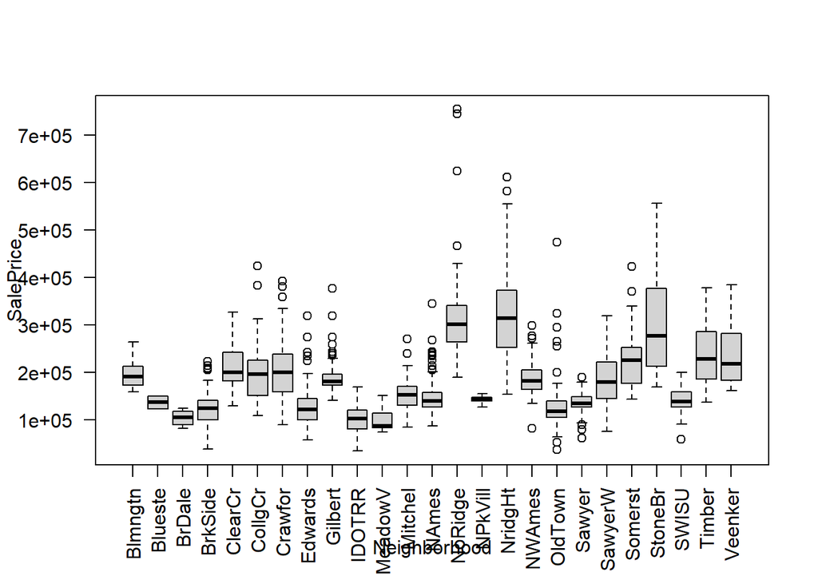

```r
plot(SalePrice~Neighborhood, train_df, las=2)
```

```r
lm.1stflr <- lm(SalePrice ~ X1stFlrSF, data=train_df) # 0.3666
summary(lm.1stflr)
```

```
##
## Call:
## lm(formula = SalePrice ~ X1stFlrSF, data = train_df)
##
## Residuals:
##     Min      1Q  Median      3Q     Max
## -460330  -36494  -13164   36291  414547
##
## Coefficients:
##              Estimate Std. Error t value Pr(>|t|)
## (Intercept) 36173.447   5245.728   6.896 7.95e-12 ***
## X1stFlrSF     124.501      4.282  29.078  < 2e-16 ***
## ---
## Signif. codes:  0 '***' 0.001 '**' 0.01 '*' 0.05 '.' 0.1 ' ' 1
##
## Residual standard error: 63220 on 1458 degrees of freedom
## Multiple R-squared:  0.3671, Adjusted R-squared:  0.3666
## F-statistic: 845.5 on 1 and 1458 DF,  p-value: < 2.2e-16
```

```r
lm.2ndflr <- lm(SalePrice ~ X2ndFlrSF, data=train_df) # 0.1014
summary(lm.2ndflr)
```

```
##
## Call:
## lm(formula = SalePrice ~ X2ndFlrSF, data = train_df)
##
## Residuals:
##     Min      1Q  Median      3Q     Max
## -159576  -45756  -17756   27144  485454
##
## Coefficients:
##              Estimate Std. Error t value Pr(>|t|)
## (Intercept) 1.608e+05  2.518e+03   63.84   <2e-16 ***
## X2ndFlrSF   5.812e+01  4.517e+00   12.87   <2e-16 ***
## ---
## Signif. codes:  0 '***' 0.001 '**' 0.01 '*' 0.05 '.' 0.1 ' ' 1
##
## Residual standard error: 75310 on 1458 degrees of freedom
## Multiple R-squared:  0.102,  Adjusted R-squared:  0.1014
## F-statistic: 165.6 on 1 and 1458 DF,  p-value: < 2.2e-16
```

```r
lm.basement <- lm(SalePrice ~ TotalBsmtSF, data=train_df) #0.3761
summary(lm.basement)
```

```
##
## Call:
## lm(formula = SalePrice ~ TotalBsmtSF, data = train_df)
##
## Residuals:
##     Min      1Q  Median      3Q     Max
## -582310  -39612  -14095   33315  420018
##
## Coefficients:
##              Estimate Std. Error t value Pr(>|t|)
## (Intercept) 63430.629   4286.892   14.80   <2e-16 ***
## TotalBsmtSF   111.110      3.745   29.67   <2e-16 ***
## ---
## Signif. codes:  0 '***' 0.001 '**' 0.01 '*' 0.05 '.' 0.1 ' ' 1
##
## Residual standard error: 62750 on 1458 degrees of freedom
## Multiple R-squared:  0.3765, Adjusted R-squared:  0.3761
## F-statistic: 880.3 on 1 and 1458 DF,  p-value: < 2.2e-16
```

```r
#Put them all together into a high dimensional multiple regression model

lm.sqft.all <- lm(SalePrice ~ X1stFlrSF + X2ndFlrSF + TotalBsmtSF, data=train_df)
summary(lm.sqft.all)
```

```
##
## Call:
## lm(formula = SalePrice ~ X1stFlrSF + X2ndFlrSF + TotalBsmtSF,
##     data = train_df)
##
## Residuals:
##     Min      1Q  Median      3Q     Max
## -697622  -21631    -366   20427  276895
##
## Coefficients:
##               Estimate Std. Error t value Pr(>|t|)
## (Intercept) -14033.593   4492.048  -3.124  0.00182 **
## X1stFlrSF       81.786      5.861  13.955  < 2e-16 ***
## X2ndFlrSF       84.493      3.021  27.973  < 2e-16 ***
## TotalBsmtSF     66.718      5.136  12.990  < 2e-16 ***
## ---
## Signif. codes:  0 '***' 0.001 '**' 0.01 '*' 0.05 '.' 0.1 ' ' 1
##
## Residual standard error: 49310 on 1456 degrees of freedom
## Multiple R-squared:  0.6155, Adjusted R-squared:  0.6147
## F-statistic: 776.8 on 3 and 1456 DF,  p-value: < 2.2e-16
```

```r
#Or use mutate and create a new "TotalSF" variable that allows for a simple linear regression model that is just as powerful, but far easier to graph and interpret.

train_df <- train_df %>%
  mutate(TotalSF2 = X1stFlrSF + X2ndFlrSF + TotalBsmtSF)

lm.sqft <- lm(SalePrice ~ TotalSF, data=train_df) # 0.5515
summary(lm.sqft)
```

```
##
## Call:
## lm(formula = SalePrice ~ TotalSF, data = train_df)
##
## Residuals:
##     Min      1Q  Median      3Q     Max
## -529125  -28892   -1594   22899  339966
##
## Coefficients:
##             Estimate Std. Error t value Pr(>|t|)
## (Intercept) 3235.966   4419.005   0.732    0.464
## TotalSF       46.908      1.107  42.367   <2e-16 ***
## ---
## Signif. codes:  0 '***' 0.001 '**' 0.01 '*' 0.05 '.' 0.1 ' ' 1
##
## Residual standard error: 53200 on 1458 degrees of freedom
## Multiple R-squared:  0.5518, Adjusted R-squared:  0.5515
## F-statistic:  1795 on 1 and 1458 DF,  p-value: < 2.2e-16
```

```r
lm.sqft <- lm(SalePrice ~ TotalSF2, data=train_df) # 0.6117
summary(lm.sqft)
```

```
##
## Call:
## lm(formula = SalePrice ~ TotalSF2, data = train_df)
##
## Residuals:
##     Min      1Q  Median      3Q     Max
## -715562  -22190    -669   20711  269879
##
## Coefficients:
##               Estimate Std. Error t value Pr(>|t|)
## (Intercept) -13219.802   4251.189   -3.11  0.00191 **
## TotalSF2        75.628      1.577   47.95  < 2e-16 ***
## ---
## Signif. codes:  0 '***' 0.001 '**' 0.01 '*' 0.05 '.' 0.1 ' ' 1
##
## Residual standard error: 49510 on 1458 degrees of freedom
## Multiple R-squared:  0.6119, Adjusted R-squared:  0.6117
## F-statistic:  2299 on 1 and 1458 DF,  p-value: < 2.2e-16
```

```r
lm.misc <- lm(SalePrice ~ MiscFeature, data=train_df) # 0.06148
summary(lm.misc)
```

```
##
## Call:
## lm(formula = SalePrice ~ MiscFeature, data = train_df)
##
## Residuals:
##    Min     1Q Median     3Q    Max
## -95195 -31063  -5188  20422 125812
##
## Coefficients:
##                 Estimate Std. Error t value Pr(>|t|)
## (Intercept)       170750      36304   4.703 2.05e-05 ***
## MiscFeatureOthr   -76750      51342  -1.495    0.141
## MiscFeatureShed   -19562      37037  -0.528    0.600
## MiscFeatureTenC    79250      62880   1.260    0.213
## ---
## Signif. codes:  0 '***' 0.001 '**' 0.01 '*' 0.05 '.' 0.1 ' ' 1
##
## Residual standard error: 51340 on 50 degrees of freedom
##   (1406 observations deleted due to missingness)
## Multiple R-squared:  0.1146, Adjusted R-squared:  0.06148
## F-statistic: 2.157 on 3 and 50 DF,  p-value: 0.1047
```

```r
lm.saletype <- lm(SalePrice ~ SaleType, data=train_df) # 0.1325
summary(lm.saletype)
```

```
##
## Call:
## lm(formula = SalePrice ~ SaleType, data = train_df)
##
## Residuals:
##     Min      1Q  Median      3Q     Max
## -161945  -46402  -15402   31598  581598
##
## Coefficients:
##               Estimate Std. Error t value Pr(>|t|)
## (Intercept)   143973.3    11283.5  12.760   <2e-16 ***
## SaleTypeCon   125626.7    53522.6   2.347   0.0191 *
## SaleTypeConLD  -5192.4    27122.3  -0.191   0.8482
## SaleTypeConLI  56416.7    34960.8   1.614   0.1068
## SaleTypeConLw   -273.3    34960.8  -0.008   0.9938
## SaleTypeCWD    66626.7    38678.1   1.723   0.0852 .
## SaleTypeNew   130972.2    13122.2   9.981   <2e-16 ***
## SaleTypeOth   -24123.3    44183.9  -0.546   0.5852
## SaleTypeWD     29428.6    11473.4   2.565   0.0104 *
## ---
## Signif. codes:  0 '***' 0.001 '**' 0.01 '*' 0.05 '.' 0.1 ' ' 1
##
## Residual standard error: 73990 on 1451 degrees of freedom
## Multiple R-squared:  0.1373, Adjusted R-squared:  0.1325
## F-statistic: 28.86 on 8 and 1451 DF,  p-value: < 2.2e-16
```

```r
# CentralAir
lm.CentralAir <- lm(SalePrice ~ CentralAir, data=train_df) # 0.06252
summary(lm.CentralAir)
```

```
##
## Call:
## lm(formula = SalePrice ~ CentralAir, data = train_df)
##
## Residuals:
##     Min      1Q  Median      3Q     Max
## -134187  -51187  -16187   30394  568813
##
## Coefficients:
##             Estimate Std. Error t value Pr(>|t|)
## (Intercept)   105264       7892  13.339   <2e-16 ***
## CentralAirY    80923       8162   9.915   <2e-16 ***
## ---
## Signif. codes:  0 '***' 0.001 '**' 0.01 '*' 0.05 '.' 0.1 ' ' 1
##
## Residual standard error: 76920 on 1458 degrees of freedom
## Multiple R-squared:  0.06317,    Adjusted R-squared:  0.06252
## F-statistic: 98.31 on 1 and 1458 DF,  p-value: < 2.2e-16
```

```r
HeatingQC <- lm(SalePrice ~ HeatingQC, data=train_df) # 0.1933
summary(HeatingQC)
```

```
##
## Call:
## lm(formula = SalePrice ~ HeatingQC, data = train_df)
##
## Residuals:
##     Min      1Q  Median      3Q     Max
## -148414  -42363  -10611   25086  540086
##
## Coefficients:
##             Estimate Std. Error t value Pr(>|t|)
## (Intercept)   214914       2621  81.990   <2e-16 ***
## HeatingQCFa   -90995      10525  -8.646   <2e-16 ***
## HeatingQCGd   -58056       5291 -10.972   <2e-16 ***
## HeatingQCPo  -127914      71401  -1.791   0.0734 .
## HeatingQCTA   -72552       4332 -16.748   <2e-16 ***
## ---
## Signif. codes:  0 '***' 0.001 '**' 0.01 '*' 0.05 '.' 0.1 ' ' 1
##
## Residual standard error: 71350 on 1455 degrees of freedom
## Multiple R-squared:  0.1955, Adjusted R-squared:  0.1933
## F-statistic: 88.39 on 4 and 1455 DF,  p-value: < 2.2e-16
```

```r
lm.Heating <- lm(SalePrice ~ Heating, data=train_df)
summary(lm.Heating)
```

```
##
## Call:
## lm(formula = SalePrice ~ Heating, data = train_df)
##
## Residuals:
##     Min      1Q  Median      3Q     Max
## -147121  -50729  -17076   31979  572979
##
## Coefficients:
##             Estimate Std. Error t value Pr(>|t|)
## (Intercept)    72500      79002   0.918    0.359
## HeatingGasA   109521      79030   1.386    0.166
## HeatingGasW    94132      81167   1.160    0.246
## HeatingGrav     2771      84457   0.033    0.974
## HeatingOthW    53250      96758   0.550    0.582
## HeatingWall    19600      88327   0.222    0.824
##
## Residual standard error: 79000 on 1454 degrees of freedom
## Multiple R-squared:  0.01444,    Adjusted R-squared:  0.01105
## F-statistic:  4.26 on 5 and 1454 DF,  p-value: 0.0007535
```

```r
#Notice as well how mutate can be used to change complicated variables into simple on-off switches.

train_df <- train_df %>%
  mutate(TotalSF = X1stFlrSF + X2ndFlrSF + TotalBsmtSF,
                RichNbrhd = case_when(Neighborhood %in% c("StoneBr", "NridgHt", "NoRidge") ~ 1,
                                                          TRUE ~ 0))

lm.sqft.rich <- lm(SalePrice ~ TotalSF + RichNbrhd + TotalSF:RichNbrhd, data=train_df)
summary(lm.sqft.rich)
```

```
##
## Call:
## lm(formula = SalePrice ~ TotalSF + RichNbrhd + TotalSF:RichNbrhd,
##     data = train_df)
##
## Residuals:
##     Min      1Q  Median      3Q     Max
## -532130  -21090    -866   20892  213493
##
## Coefficients:
##                     Estimate Std. Error t value Pr(>|t|)
## (Intercept)        2.704e+04  4.078e+03   6.630 4.73e-11 ***
## TotalSF            5.659e+01  1.594e+00  35.504  < 2e-16 ***
## RichNbrhd         -1.207e+05  1.695e+04  -7.122 1.66e-12 ***
## TotalSF:RichNbrhd  5.735e+01  4.696e+00  12.212  < 2e-16 ***
## ---
## Signif. codes:  0 '***' 0.001 '**' 0.01 '*' 0.05 '.' 0.1 ' ' 1
##
## Residual standard error: 42500 on 1456 degrees of freedom
## Multiple R-squared:  0.7143, Adjusted R-squared:  0.7137
## F-statistic:  1214 on 3 and 1456 DF,  p-value: < 2.2e-16
```

```r
# OverallCond
lm.OverallCond <- lm(SalePrice ~ OverallCond, data=train_df) # 0.005 r-squared
summary(lm.OverallCond)
```

```
##
## Call:
## lm(formula = SalePrice ~ OverallCond, data = train_df)
##
## Residuals:
##     Min      1Q  Median      3Q     Max
## -159924  -49459  -16590   30881  576439
##
## Coefficients:
##             Estimate Std. Error t value Pr(>|t|)
## (Intercept)   211910      10597  19.997  < 2e-16 ***
## OverallCond    -5558       1864  -2.982  0.00291 **
## ---
## Signif. codes:  0 '***' 0.001 '**' 0.01 '*' 0.05 '.' 0.1 ' ' 1
##
## Residual standard error: 79230 on 1458 degrees of freedom
## Multiple R-squared:  0.006062,   Adjusted R-squared:  0.00538
## F-statistic: 8.892 on 1 and 1458 DF,  p-value: 0.002912
```

```r
# OverallQual
lm.OverallQual <- lm(SalePrice ~ OverallQual, data=train_df) #### 0.6254 r-squared ######
summary(lm.OverallQual)
```

```
##
## Call:
## lm(formula = SalePrice ~ OverallQual, data = train_df)
##
## Residuals:
##     Min      1Q  Median      3Q     Max
## -198152  -29409   -1845   21463  396848
##
## Coefficients:
##             Estimate Std. Error t value Pr(>|t|)
## (Intercept) -96206.1     5756.4  -16.71   <2e-16 ***
## OverallQual  45435.8      920.4   49.36   <2e-16 ***
## ---
## Signif. codes:  0 '***' 0.001 '**' 0.01 '*' 0.05 '.' 0.1 ' ' 1
##
## Residual standard error: 48620 on 1458 degrees of freedom
## Multiple R-squared:  0.6257, Adjusted R-squared:  0.6254
## F-statistic:  2437 on 1 and 1458 DF,  p-value: < 2.2e-16
```